# 04_Biodiversity

Jayden William Kgobe

2026-04-23

# Goals

Run an analysis on the within-sample biodiversity of the samples in our project.

## Outputs

*This is an exciting analysis!!! We finally get to answer one of our scientific questions!*

1. Calculated biodiversity measures (Hill numbers) across every sample.
2. Figures to include in our scientific paper that visualize the data as it relates to the scientific question.
3. Statistical tests conveying the measured and quantified changes and patterns in biodiversity.

# Scientific Question

How does rumen microbial alpha diversity vary among the three anonymous sample groups (J, Y, and L)?

## Question & Hypotheses

### Null Hypothesis

There are no significant differences in rumen microbial alpha diversity among sample groups J, Y, and L.

### Alternative Hypothesis

At least one of the sample groups (J, Y, or L) exhibits significantly different rumen microbial alpha diversity compared with the others.

# Set up the Environment

## Timing of this script

```r
# What time did we start running this script?
start_time <- Sys.time()
```

## Set the seed

```r
set.seed(2356728)
```

## Load Packages & Colors

```r
# load packages
pacman::p_load(tidyverse, devtools, patchwork, iNEXT, phyloseq,
               # packages for stats
               ggpubr, rstatix, install = FALSE)

# Load in colors for plotting
source("code/colors_and_shapes.R")
```

## Load in Data

```r
load("data/03_PreProcessing/preprocessed_phyloseq.RData")

# take a look at it!
preprocessed_physeq
```

```
## phyloseq-class experiment-level object
## otu_table()   OTU Table:         [ 4076 taxa and 60 samples ]
## sample_data() Sample Data:       [ 60 samples by 35 sample variables ]
## tax_table()   Taxonomy Table:    [ 4076 taxa by 9 taxonomic ranks ]
```

```r
# Intuition check on seq depth
min(sample_sums(preprocessed_physeq))
```

```
## [1] 8642
```

```r
# Make a metadata dataframe
metadata_df <-
  preprocessed_physeq %>%
  sample_data() %>%
  data.frame()

# view of it
glimpse(metadata_df)
```

```
## Rows: 60
## Columns: 35
## $ Assay.Type                     <chr> "AMPLICON", "AMPLICON", "AMPLICON", "AM…
## $ AvgSpotLen                     <int> 602, 602, 602, 602, 602, 602, 602, 602,…
## $ Bases                          <int> 35796726, 34279084, 34860616, 34168316,…
## $ BioProject                     <chr> "PRJNA669201", "PRJNA669201", "PRJNA669…
## $ BioSample                      <chr> "SAMN16456667", "SAMN16456670", "SAMN16…
## $ BioSampleModel                 <chr> "Metagenome or environmental", "Metagen…
## $ Bytes                          <int> 17643438, 16964323, 17192858, 16798896,…
## $ Center.Name                    <chr> "ANSHAN BIOTECHNOLOGY CO. LTD", "ANSHAN…
## $ Collection_Date                <chr> "9/28/19", "9/28/19", "9/28/19", "9/28/…
## $ Consent                        <chr> "public", "public", "public", "public",…
## $ DATASTORE.filetype             <chr> "fastq,run.zq,sra", "fastq,run.zq,sra",…
## $ DATASTORE.provider             <chr> "gs,ncbi,s3", "gs,ncbi,s3", "gs,ncbi,s3…
## $ DATASTORE.region               <chr> "gs.us-east1,ncbi.public,s3.us-east-1",…
```

[output cut: 22 more lines]

# Biodiversity Hill Numbers with iNEXT

## Hill Number Equation

Next, we will calculate the biodiversity with the [iNEXT package](https://besjournals.onlinelibrary.wiley.com/doi/full/10.1111/2041-210X.12613) package. iNEXT focuses on three measures of biodiversity via the Hill numbers. Hill numbers have the order q:

$${}^qD = \left( \sum_{i=1}^{S} p_i^q \right)^{1/(1 - q)}, \quad q \geq 0,
\quad q \neq 1.$$

But when *q = 1*, then the equation is:

$${}^1D = \lim_{q \to 1} {}^qD = \exp\left( - \sum_{i=1}^{S} p_i \log p_i
\right) = \exp(H_{sh}).$$

**Where:**

- ${}^qD$ is the *Hill number* or *diversity of order $q$*, a measure of species diversity.
- $q$ is the *order of diversity*, which determines how sensitive the measure is to species relative abundances:
  - $q = 0$: all species are weighted equally or **species richness**,
  - $q = 1$: corresponds to the exponential of **Shannon entropy**,
  - $q = 2$: corresponds to the **inverse of Simpson’s index**.
- $S$ is the *total number of species* in the community.
- $p_i$ is the *relative abundance* of species $i$, i.e., the proportion of individuals in the community belonging to species $i$.

## Microbial Example 🦠

Imagine you’re studying the microbial diversity in three sourdough starters from three different bakers: A, B, and C. Each one contains a mix of **ASVs**. *But how diverse are they, really?* Here,’s a great application of the **Hill numbers** to find out, varying the value of $q$.

### When $q = 0$: Counting *All* ASVs Equally

> *Species Richness* → ${}^0D$

Here, we ignore how common or rare each ASV is. Every ASV counts equally — even ones that appear just once. For example, this is like walking into a library and simply counting how many unique book titles are on the shelves—not how many copies of each exist, just the number of different titles. So, even if there’s only one copy of most books and 100 copies of one, they all count the same.

Here, in the context of microbial communities, we are pondering: **“How many different ASVs are present?”** We do not weight them by abundance/evenness in any way. Rather, we focus on a binary measures of 0s and 1s that represent presence (1) and absence (0).

- Baker A’s starter has 10 unique ASVs: ${}^0D_{\text{A}} = 10$
- Baker B’s has 7 unique ASVs: ${}^0D_{\text{B}} = 7$
- Baker C’s has 15 unique ASVs: ${}^0D_{\text{C}} = 15$

### When $q = 1$: Balancing Rarity and Commonness

> *Shannon Diversity* → ${}^1D$

Now we ask: **“How evenly are the ASVs distributed?”** Rare ASVs matter, but not as much as common ones. If we revisit the library analogy, now imagine you’re randomly picking books off the shelves to read. Some books have many more copies, so you’re more likely to pick those — but you still have a chance to encounter the rare ones. This measure reflects both richness and evenness — it tells you the effective number of “common” book titles based on their relative frequency. `q = 1` gives you a sense of how diverse your reading experience would be, considering popular vs. rare titles.

- Baker A’s 10 ASVs are 90% dominated by just one ASV: ${}^1D_{\text{A}} \approx 2$
- Baker B’s 7 ASVs are fairly even: ${}^1D_{\text{B}} \approx 6.8$
- Baker C’s 15 ASVs include 3 very dominant ones: ${}^1D_{\text{C}} \approx 5$

Even though Baker C and A have more ASVs in terms of richness in ${}^0D$, **Baker B** has the highest ${}^1D$ due to better balance between the abundances of its seven ASVs.

### When $q = 2$: Focus on the Most Abundant ASVs

> *Simpson-like Diversity* → ${}^2D$

Now we modify our question to wonder: **How many ASVs dominate each sample?** Here, rare ASVs hardly matter. For example, this is like walking into the library and only noticing the most abundant book titles, because they take up entire shelves. The rare titles are barely visible. Therefore, this measure emphasizes dominant species—those with many copies. `q = 2` tells us the effective number of dominant book titles, downplaying the presence of rare ones.

- Baker A’s starter is almost all one ASV of 10 total ASVs: ${}^2D_{\text{A}} \approx 1.2$
- Baker B’s 7 ASVs are balanced: ${}^2D_{\text{B}} \approx 6.5$
- Baker C’s has 3 dominant ASVs out of 15: ${}^2D_{\text{C}} \approx 3.5$

This tells us: **Baker B** has the most diverse community in terms of its *dominant* community members.

## Hill Number Summary Table

| Value of $q$ | Emphasis | Hill Number ${}^qD$ | Interpretation |
| --- | --- | --- | --- |
| $q = 0$ | Every ASV counts equally | ${}^0D$ | ASV richness — a simple count |
| $q = 1$ | Balance of common & rare | ${}^1D$ | Shannon Diversity — balanced view |
| $q = 2$ | Dominant ASVs matter most | ${}^2D$ | Simpson Diversity — focus on major players |

So, hopefully you can see that using Hill numbers like ${}^qD$ gives you a powerful, flexible way to describe microbial diversity — from just counting ASVs to understanding community structure. Next, we will calculate the biodiversity with the [iNEXT package](https://besjournals.onlinelibrary.wiley.com/doi/full/10.1111/2041-210X.12613) package. iNEXT focuses on three measures of biodiversity via the Hill numbers. For each Hill NUmber [iNEXT package](https://besjournals.onlinelibrary.wiley.com/doi/full/10.1111/2041-210X.12613) uses the observed abundance of species within a sample to compute diversity estimates and the associated 95% confidence intervals for the following two types of rarefaction and extrapolation (R/E):

1. **Sample-size-based (or size-based) R/E curves**: iNEXT computes diversity estimates for rarefied and extrapolated samples up to an appropriate size (2x the total number of individuals/sequences in that sample). This type of sampling curve plots the diversity estimates with respect to sample size.
2. **Coverage‐based R/E curves:** iNEXT computes diversity estimates for rarefied and extrapolated samples based on a standardized level of sample completeness (as measured by sample coverage) up to an appropriate coverage value. This type of sampling curve plots the diversity estimates with respect to sample coverage. **NOTE: Coverage is inapplicable to DADA2 datasets, as they lack singletons** (this is also why we can’t use Amy Willis’s breakaway approach).

*An important note:* We’ll be using the size_based output. Our lab has previously been suspicious of the Asymptotic Estimator. Therefore we will use the size_based approach here, with the caveat that we will very rigorously confirm that we’ve approached saturation for all of our samples!

> Warning! iNEXT takes a while to run, especially if your samples are deeply sequenced or if you have many samples! It is wise to calculate iNEXT early and then come back to the rest of the home work later on.

```r
# prepare the input data
# Species in rows and the samples in columns
iNEXT_input_df <-
  preprocessed_physeq %>%
  otu_table() %>%
  data.frame()

# Inpect
dim(iNEXT_input_df)
```

```
## [1] 4076   60
```

```r
iNEXT_input_df[1:5, 1:5]
```

```
##          SRR12873146 SRR12873147 SRR12873148 SRR12873149 SRR12873150
## ASV_0001         462         149         386         258        1315
## ASV_0002         438         104         419         266        1098
## ASV_0003         324         278         177         212         692
## ASV_0004         258          83         230         162         547
## ASV_0005         227          20          66         203         165
```

```r
# Run iNEXT
# Remember to set the seed!
# ASVs in ROWs, samples in COLUMNS
#iNEXT_data <- iNEXT(iNEXT_input_df,
#                  q = c(0, 1, 2),
#                   datatype = "abundance")

# Save the object for later!
# Make the directory first in shell! Otherwise there will be an error
#save(iNEXT_data, file = "data/04_Biodiversity/iNEXT_data.RData")
```

Since iNEXT takes a while to run, we will load in the data that was calculated before!

```r
load("data/04_Biodiversity/iNEXT_data.RData")

# Inspect
str(iNEXT_data)
```

```
## List of 3
##  $ DataInfo:'data.frame':    60 obs. of  14 variables:
##   ..$ Assemblage: chr [1:60] "SRR12873146" "SRR12873147" "SRR12873148" "SRR12873149" ...
##   ..$ n         : num [1:60] 16322 15277 15607 16816 17655 ...
##   ..$ S.obs     : num [1:60] 659 612 587 609 612 496 528 371 428 372 ...
##   ..$ SC        : num [1:60] 0.999 0.999 0.999 0.999 1 ...
##   ..$ f1        : num [1:60] 12 10 11 18 9 13 9 2 4 3 ...
##   ..$ f2        : num [1:60] 10 14 6 19 11 9 10 5 5 10 ...
##   ..$ f3        : num [1:60] 18 15 18 12 18 18 10 8 11 14 ...
##   ..$ f4        : num [1:60] 20 26 20 16 23 19 20 11 19 6 ...
##   ..$ f5        : num [1:60] 28 25 25 24 40 19 21 15 24 14 ...
##   ..$ f6        : num [1:60] 31 28 20 21 24 26 22 19 18 18 ...
##   ..$ f7        : num [1:60] 36 27 25 34 28 25 29 17 21 15 ...
##   ..$ f8        : num [1:60] 31 22 25 28 22 22 22 13 17 14 ...
##   ..$ f9        : num [1:60] 28 30 24 21 28 26 18 16 19 14 ...
##   ..$ f10       : num [1:60] 40 31 21 25 24 20 17 6 19 22 ...
##  $ iNextEst:List of 2
##   ..$ size_based    :'data.frame':   7200 obs. of  10 variables:
##   .. ..$ Assemblage: chr [1:7200] "SRR12873146" "SRR12873146" "SRR12873146" "SRR12873146" ...
##   .. ..$ m         : num [1:7200] 1 907 1814 2721 3627 ...
##   .. ..$ Method    : chr [1:7200] "Rarefaction" "Rarefaction" "Rarefaction" "Rarefaction" ...
##   .. ..$ Order.q   : num [1:7200] 0 0 0 0 0 0 0 0 0 0 ...
##   .. ..$ qD        : num [1:7200] 1 375 497 557 591 ...
##   .. ..$ qD.LCL    : num [1:7200] 1 372 492 552 586 ...
##   .. ..$ qD.UCL    : num [1:7200] 1 379 502 563 597 ...
##   .. ..$ SC        : num [1:7200] 0.00514 0.79947 0.91051 0.95167 0.97124 ...
##   .. ..$ SC.LCL    : num [1:7200] 0.00491 0.79654 0.90894 0.95066 0.97044 ...
##   .. ..$ SC.UCL    : num [1:7200] 0.00537 0.8024 0.91209 0.95268 0.97205 ...
##   ..$ coverage_based:'data.frame':   7200 obs. of  8 variables:
##   .. ..$ Assemblage: chr [1:7200] "SRR12873146" "SRR12873146" "SRR12873146" "SRR12873146" ...
##   .. ..$ SC        : num [1:7200] 0.00514 0.79947 0.91051 0.95167 0.97124 ...
##   .. ..$ m         : num [1:7200] 1 907 1814 2721 3627 ...
##   .. ..$ Method    : chr [1:7200] "Rarefaction" "Rarefaction" "Rarefaction" "Rarefaction" ...
##   .. ..$ Order.q   : num [1:7200] 0 0 0 0 0 0 0 0 0 0 ...
##   .. ..$ qD        : num [1:7200] 1 375 497 557 591 ...
##   .. ..$ qD.LCL    : num [1:7200] 0.983 369.465 490.865 550.946 585.121 ...
##   .. ..$ qD.UCL    : num [1:7200] 1.02 381.01 503.55 563.44 597.19 ...
##  $ AsyEst  :'data.frame':    180 obs. of  7 variables:
##   ..$ Assemblage: chr [1:180] "SRR12873146" "SRR12873146" "SRR12873146" "SRR12873147" ...
##   ..$ Diversity : chr [1:180] "Species richness" "Shannon diversity" "Simpson diversity" "Species richness" ...
##   ..$ Observed  : num [1:180] 659 369 192 612 361 ...
##   ..$ Estimator : num [1:180] 666 377 195 616 369 ...
##   ..$ s.e.      : num [1:180] 6.04 3.25 4.15 5.3 2.81 ...
##   ..$ LCL       : num [1:180] 659 370 187 612 363 ...
##   ..$ UCL       : num [1:180] 678 383 203 626 374 ...
##  - attr(*, "class")= chr "iNEXT"
```

```r
typeof(iNEXT_data)
```

```
## [1] "list"
```

# Rarefaction Curves

## `ggiNEXT` Rarefaction Curves

```r
# Prepare Colors
color_df <-
  iNEXT_input_df %>%
  colnames() %>%
  data.frame()

# Check
head(color_df)
```

```
##             .
## 1 SRR12873146
## 2 SRR12873147
## 3 SRR12873148
## 4 SRR12873149
## 5 SRR12873150
## 6 SRR12873151
```

```r
# Rename the column
colnames(color_df)[1] <- "names"

# Check
head(color_df)
```

```
##         names
## 1 SRR12873146
## 2 SRR12873147
## 3 SRR12873148
## 4 SRR12873149
## 5 SRR12873150
## 6 SRR12873151
```

```r
metadata_df
```

[output not shown]

[output cut: 494 more lines]

```
## SRR12873191         7                 27 SRP288032 SRR12873191
## SRR12873192         6                 26 SRP288032 SRR12873192
## SRR12873193         5                 25 SRP288032 SRR12873193
## SRR12873194         4                 24 SRP288032 SRR12873194
## SRR12873195         3                 23 SRP288032 SRR12873195
## SRR12873196         2                 22 SRP288032 SRR12873196
## SRR12873197         1                 21 SRP288032 SRR12873197
## SRR12873198         3                  3 SRP288032 SRR12873198
## SRR12873199        20                 20 SRP288032 SRR12873199
## SRR12873200        19                 19 SRP288032 SRR12873200
## SRR12873201        18                 18 SRP288032 SRR12873201
## SRR12873202        17                 17 SRP288032 SRR12873202
## SRR12873203        16                 16 SRP288032 SRR12873203
## SRR12873204        15                 15 SRP288032 SRR12873204
## SRR12873205        14                 14 SRP288032 SRR12873205
```

```r
colnames(color_df)
```

```
## [1] "names"
```

```r
colnames(metadata_df)
```

```
##  [1] "Assay.Type"                     "AvgSpotLen"
##  [3] "Bases"                          "BioProject"
##  [5] "BioSample"                      "BioSampleModel"
##  [7] "Bytes"                          "Center.Name"
##  [9] "Collection_Date"                "Consent"
## [11] "DATASTORE.filetype"             "DATASTORE.provider"
## [13] "DATASTORE.region"               "Experiment"
## [15] "geo_loc_name_country"           "geo_loc_name_country_continent"
## [17] "geo_loc_name"                   "Host"
## [19] "Instrument"                     "isolation_source"
## [21] "lat_lon"                        "Library.Name"
## [23] "LibraryLayout"                  "LibrarySelection"
## [25] "LibrarySource"                  "Organism"
## [27] "Platform"                       "ReleaseDate"
## [29] "create_date"                    "version"
## [31] "Group"                          "Replicate"
## [33] "source_material_id"             "SRA.Study"
## [35] "SampleID"
```

```r
group_colors <- c(
  "J" = "#A8E6CE",   # light mint
  "L"      = "#56C1D3",   # aqua
  "Y"     = "#08306B")    # deep navy

iNEXT_color_df <-
  color_df %>%
  mutate(
    names = gsub(pattern = "[.]", replace = "-", x = names),
    names = gsub(pattern = "^X", replace = "", x = names)
  ) %>%
  rename(SampleID = names) %>%
  left_join(metadata_df, by = "SampleID") %>%
  left_join(
    data.frame(
      group_colors = group_colors,
      Group = names(group_colors)
    ),
    by = "Group"
  )

head(iNEXT_color_df)
```

```
##      SampleID Assay.Type AvgSpotLen    Bases  BioProject    BioSample
## 1 SRR12873146   AMPLICON        602 35796726 PRJNA669201 SAMN16456667
## 2 SRR12873147   AMPLICON        602 34279084 PRJNA669201 SAMN16456670
## 3 SRR12873148   AMPLICON        602 34860616 PRJNA669201 SAMN16456666
## 4 SRR12873149   AMPLICON        602 34168316 PRJNA669201 SAMN16456665
## 5 SRR12873150   AMPLICON        602 35598668 PRJNA669201 SAMN16456664
## 6 SRR12873151   AMPLICON        602 23012654 PRJNA669201 SAMN16456717
##                BioSampleModel    Bytes                  Center.Name
## 1 Metagenome or environmental 17643438 ANSHAN BIOTECHNOLOGY CO. LTD
## 2 Metagenome or environmental 16964323 ANSHAN BIOTECHNOLOGY CO. LTD
## 3 Metagenome or environmental 17192858 ANSHAN BIOTECHNOLOGY CO. LTD
## 4 Metagenome or environmental 16798896 ANSHAN BIOTECHNOLOGY CO. LTD
## 5 Metagenome or environmental 17521879 ANSHAN BIOTECHNOLOGY CO. LTD
## 6 Metagenome or environmental 11333323 ANSHAN BIOTECHNOLOGY CO. LTD
##   Collection_Date Consent DATASTORE.filetype DATASTORE.provider
```

[output cut: 48 more lines]

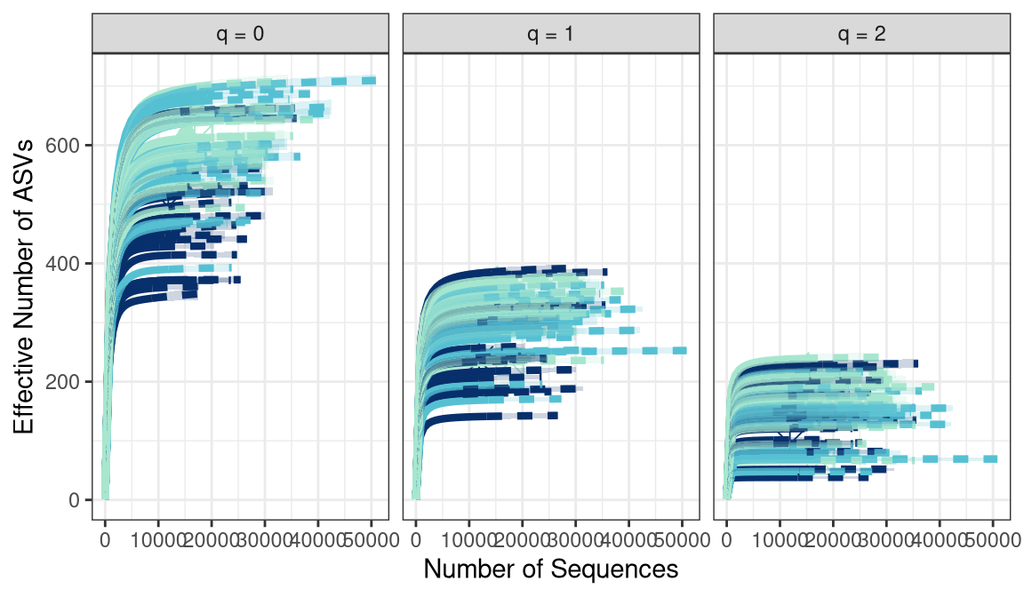

```r
ggiNEXT(iNEXT_data, type = 1, facet.var = "Order.q") +
  scale_color_manual(values = iNEXT_color_df$group_colors) +
  scale_fill_manual(values = iNEXT_color_df$group_colors) +
  theme_bw() +
  theme(legend.position = "none") +
  labs(y = "Effective Number of ASVs", x = "Number of Sequences")
```

Remembering that an Order q of:

- 0 = Richness/ Number of Total taxa
- 1 = Exponential Shannon / Number of “Common” taxa
- 2 = Inverse Simpson / Number of “Dominant” taxa

*Also note that iNEXT will extrapolate the number of sequences to double the sequencing depth of the sample!* This extrapolation is represented by the dotted line, which extends to 2 x the library size of the sample.

Ok, this plot is nice, but since it’s autogenerated with the `ggiNEXT` function, I’d like some more freedom to plot and explore the data further. Let’s manually plot the data that we pull out from the iNEXT data.

## Manual Rarefaction Curves

```r
str(iNEXT_data)
```

```
## List of 3
##  $ DataInfo:'data.frame':    60 obs. of  14 variables:
##   ..$ Assemblage: chr [1:60] "SRR12873146" "SRR12873147" "SRR12873148" "SRR12873149" ...
##   ..$ n         : num [1:60] 16322 15277 15607 16816 17655 ...
##   ..$ S.obs     : num [1:60] 659 612 587 609 612 496 528 371 428 372 ...
##   ..$ SC        : num [1:60] 0.999 0.999 0.999 0.999 1 ...
##   ..$ f1        : num [1:60] 12 10 11 18 9 13 9 2 4 3 ...
##   ..$ f2        : num [1:60] 10 14 6 19 11 9 10 5 5 10 ...
##   ..$ f3        : num [1:60] 18 15 18 12 18 18 10 8 11 14 ...
##   ..$ f4        : num [1:60] 20 26 20 16 23 19 20 11 19 6 ...
##   ..$ f5        : num [1:60] 28 25 25 24 40 19 21 15 24 14 ...
##   ..$ f6        : num [1:60] 31 28 20 21 24 26 22 19 18 18 ...
##   ..$ f7        : num [1:60] 36 27 25 34 28 25 29 17 21 15 ...
##   ..$ f8        : num [1:60] 31 22 25 28 22 22 22 13 17 14 ...
##   ..$ f9        : num [1:60] 28 30 24 21 28 26 18 16 19 14 ...
##   ..$ f10       : num [1:60] 40 31 21 25 24 20 17 6 19 22 ...
##  $ iNextEst:List of 2
##   ..$ size_based    :'data.frame':   7200 obs. of  10 variables:
##   .. ..$ Assemblage: chr [1:7200] "SRR12873146" "SRR12873146" "SRR12873146" "SRR12873146" ...
##   .. ..$ m         : num [1:7200] 1 907 1814 2721 3627 ...
##   .. ..$ Method    : chr [1:7200] "Rarefaction" "Rarefaction" "Rarefaction" "Rarefaction" ...
##   .. ..$ Order.q   : num [1:7200] 0 0 0 0 0 0 0 0 0 0 ...
##   .. ..$ qD        : num [1:7200] 1 375 497 557 591 ...
##   .. ..$ qD.LCL    : num [1:7200] 1 372 492 552 586 ...
##   .. ..$ qD.UCL    : num [1:7200] 1 379 502 563 597 ...
##   .. ..$ SC        : num [1:7200] 0.00514 0.79947 0.91051 0.95167 0.97124 ...
##   .. ..$ SC.LCL    : num [1:7200] 0.00491 0.79654 0.90894 0.95066 0.97044 ...
##   .. ..$ SC.UCL    : num [1:7200] 0.00537 0.8024 0.91209 0.95268 0.97205 ...
##   ..$ coverage_based:'data.frame':   7200 obs. of  8 variables:
##   .. ..$ Assemblage: chr [1:7200] "SRR12873146" "SRR12873146" "SRR12873146" "SRR12873146" ...
##   .. ..$ SC        : num [1:7200] 0.00514 0.79947 0.91051 0.95167 0.97124 ...
##   .. ..$ m         : num [1:7200] 1 907 1814 2721 3627 ...
##   .. ..$ Method    : chr [1:7200] "Rarefaction" "Rarefaction" "Rarefaction" "Rarefaction" ...
##   .. ..$ Order.q   : num [1:7200] 0 0 0 0 0 0 0 0 0 0 ...
##   .. ..$ qD        : num [1:7200] 1 375 497 557 591 ...
##   .. ..$ qD.LCL    : num [1:7200] 0.983 369.465 490.865 550.946 585.121 ...
##   .. ..$ qD.UCL    : num [1:7200] 1.02 381.01 503.55 563.44 597.19 ...
##  $ AsyEst  :'data.frame':    180 obs. of  7 variables:
##   ..$ Assemblage: chr [1:180] "SRR12873146" "SRR12873146" "SRR12873146" "SRR12873147" ...
##   ..$ Diversity : chr [1:180] "Species richness" "Shannon diversity" "Simpson diversity" "Species richness" ...
##   ..$ Observed  : num [1:180] 659 369 192 612 361 ...
##   ..$ Estimator : num [1:180] 666 377 195 616 369 ...
##   ..$ s.e.      : num [1:180] 6.04 3.25 4.15 5.3 2.81 ...
##   ..$ LCL       : num [1:180] 659 370 187 612 363 ...
##   ..$ UCL       : num [1:180] 678 383 203 626 374 ...
##  - attr(*, "class")= chr "iNEXT"
```

```r
iNEXT_manual_df <-
  iNEXT_data$iNextEst$size_based %>%
  dplyr::rename(names = Assemblage) %>%
  # fix the samples to merge with metadata
  mutate(
    names = gsub("[.]", "-", names),
    names = gsub("X", "", names)
  ) %>%
  # join with the metadata
  left_join(metadata_df, by = c("names" = "SampleID"))

# Inspection
dim(iNEXT_manual_df)
```

```
## [1] 7200   44
```

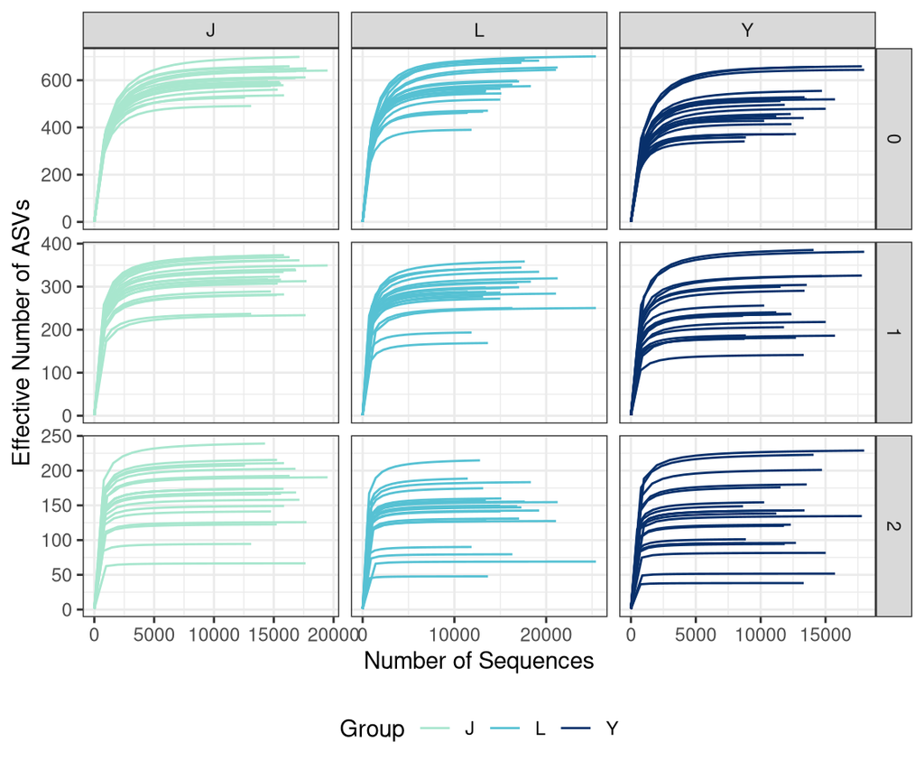

```r
# Manually plot rarefaction curves
iNEXT_manual_df %>%
  # Filter out rows that are calculated with actual sequences (no extrapolated)
  dplyr::filter(Method == "Rarefaction") %>%
  # Now, let's draw the plot!
  ggplot(aes(x = m, y = qD, color = Group, group = names)) +
  geom_line() +
  # Facet by station
  facet_grid(Order.q~Group, scales = "free") +
  scale_color_manual(values = group_colors) +
  theme_bw() +
  labs(y = "Effective Number of ASVs",
       x = "Number of Sequences") +
  theme(legend.position = "bottom")
```

INTERPRETATION #1: What can you conclude from the ggiNEXT and manual rarefaction curve plots? Are there “enough” sequences to analyze the samples? Is it valid to make any conclusions about species richness when q = 0? What about when q = 1? Or q = 2? Why or why not?

**Summary of Observations** Both the ggiNEXT and manual rarefaction curves, most samples show a rapid initial increase followed by a clear plateau, particularly at lower sequencing depths. This indicates that:

- The majority of microbial diversity is captured early and any dditional sequencing yields diminishing returns
- Therefore, sequencing depth is generally sufficient for downstream analysis

**Observation of Richness: (q = 0)** - Some of the curves at q = 0 do not fully plateau (or maybe I am being too pedantic); they seem to to continue to rise at higher sequence depths - This observation would imply that richness is highly sensitive to rare taxa therefore, ess reliable to make definitive conclusions about species richness at q = 0, because richness is likely underestimated.

**Observation of Shannon Diversity: (q = 1)** - The curves in this case seem to plateau more constistnetly actoss samples. - It is valid to make conclusions about diversity at q = 1, as sequencing depth appears sufficient to capture the majority of ecologically relevant diversity.

**Observation of Simpson Diversity: (q = 2)** - Much more steeper curves, so the plateaus in the curves appear much more quickly. Since Simpson diversity emphasizes dominant taxa, rare taxa have little influence in this community - It is valid to make conclusions at q = 2, since dominant community structure is well captured even at lower sequencing depths.

**Conclusions** - Sequencing depth is adequate…yay!!! - However, Confidence in diversity estimates increases with higher q values: * q = 0: least reliable; since it is sensitive to rare taxa * q = 1: reliable * q = 2: reliable

# Statististical Testing

So, how do we actually quantify the changes in biodiversity that we may observe between the samples? That takes us into statistics!

## Parametric vs. Non-Parametric Statistics??

Understanding the difference between **parametric** and **non-parametric** statistics is essential for choosing the right test for your data, especially in microbial ecology where data often violate assumptions of normality.

*So, what’s the difference between the two?*

| Feature | Parametric | Non-Parametric |
| --- | --- | --- |
| **Assumptions** | Assumes a known distribution (usually normal) | Fewer assumptions about distribution |
| **Data Type** | Continuous (interval/ratio) | Ordinal or non-normal continuous |
| **Examples** | t-test, ANOVA, linear regression | Wilcoxon, Kruskal-Wallis, Spearman |
| **Estimates Based On** | Parameters like mean and variance | Ranks or medians |
| **Sensitive to Outliers?** | Yes | Less sensitive |
| **Statistical Power** | Higher if assumptions are met | Lower but more robust to violations |

### Parametric Statistics

Parametric tests assume that the data follow a specific distribution (usually a normal/Gaussian distribution). They are more statistically powerful **if those assumptions are met**. Some examples include, comparing means with a t-test or ANOVA or modeling relationships using linear regression.

```
# Example t-test on alpha diversity between two treatment groups (Shannon index)
t.test(shannon ~ treatment, data = my_data)
```

### Non-Parametric Statistics

- Data are skewed or non-normal
- Sample sizes are small
- Outliers are present
- You’re analyzing ranks (*e.g.,* ordinal data) or medians

```
# Example Wilcoxon test on alpha diversity between two treatment groups (Shannon index)
wilcox.test(shannon ~ treatment, data = my_data)
```

## How do I test if my data is “normal”?

Typically people perform a **Shapiro-Wilk Test** on their data. The Shapiro-Wilk test is a statistical test used to check whether a sample of data comes from a normally distributed population.

The Shapiro-Wilk test calculates a **W statistic** by comparing the order statistics (sorted values) of your data with those expected from a normal distribution.

- **W ≈ 1** → data is close to normal.
- **W < 1** → increasing deviation from normality.

What hypothses does the Shapiro-Wilk Test?

- *Null hypothesis (H₀):* The data are normally distributed.
  - *p-value > 0.05*: Fail to reject H₀ and the data appears normal.
- *Alternative hypothesis (H₁):* The data are *not* normally distributed.
  - *p-value < 0.05*: We can reject the H₀, which will indicate that the data is **not normal**.

**Assumption would be to assume not normally distributed because the Shapiro-Wilk test is very sensitive to small datasets like mine**

*Is the richness data normal?*

```r
### Now what about for richness?
obs_div_df <-
  iNEXT_manual_df %>%
  dplyr::filter(Method == "Observed")

# check it
glimpse(obs_div_df)
```

```
## Rows: 180
## Columns: 44
## $ names                          <chr> "SRR12873146", "SRR12873146", "SRR12873…
## $ m                              <dbl> 16322, 16322, 16322, 15277, 15277, 1527…
## $ Method                         <chr> "Observed", "Observed", "Observed", "Ob…
## $ Order.q                        <dbl> 0, 1, 2, 0, 1, 2, 0, 1, 2, 0, 1, 2, 0, …
## $ qD                             <dbl> 659.00000, 368.77834, 192.39463, 612.00…
## $ qD.LCL                         <dbl> 653.48247, 361.68878, 184.13772, 606.54…
## $ qD.UCL                         <dbl> 664.51753, 375.86789, 200.65154, 617.45…
## $ SC                             <dbl> 0.9992649, 0.9992649, 0.9992649, 0.9993…
## $ SC.LCL                         <dbl> 0.9988712, 0.9988712, 0.9988712, 0.9989…
## $ SC.UCL                         <dbl> 0.9996586, 0.9996586, 0.9996586, 0.9997…
## $ Assay.Type                     <chr> "AMPLICON", "AMPLICON", "AMPLICON", "AM…
## $ AvgSpotLen                     <int> 602, 602, 602, 602, 602, 602, 602, 602,…
## $ Bases                          <int> 35796726, 35796726, 35796726, 34279084,…
```

[output cut: 31 more lines]

```r
# Pull out unique data from the three fractions of samples
obs_whole_rich_df <-
  obs_div_df %>%
  dplyr::filter(Order.q == 0)

# Test of the data is normal for the continuous value of richness
shapiro.test(obs_whole_rich_df$qD)
```

```
##
##  Shapiro-Wilk normality test
##
## data:  obs_whole_rich_df$qD
## W = 0.95803, p-value = 0.03771
```